# ESM244 Assignment 3 Task 2

Anna Abelman

2/29/2020

### Text Analysis of Hunger Games by Suzanne Collins

PDF from: https://archive.org/details/image_201902

The purpose of this analysis is to see which words are used most frequently throughout the book as well as the overall tone of the book using a sentiment analysis.

```r
#read in the pdf
hg_path <- here("hunger games.pdf")
hg_text <- pdf_text(hg_path)

#make into data frame
hg_df <- data.frame(hg_text) %>%
  mutate(text_full = str_split(hg_text, pattern = '\\n')) %>%
  unnest(text_full) %>%
  mutate(text_full = str_trim(text_full))

#tokens data frame
hg_tokens <- hg_df %>%
  unnest_tokens(word, text_full)

#get the counts of the each word
hg_counts <- hg_tokens %>%
  count(word) %>%
  arrange(-n)
```

```r
#use stop_words to remove unnecessary words
hg_stop <- hg_tokens %>%
  anti_join(stop_words) %>%
  select(-hg_text)

#count the list of words once the stop words are removed (not working for some reason, but worked in lab)
hg_swc <- hg_stop %>%
  count(word) %>%
  arrange(-n)

#remove the numbers to only contain words
hg_no_numeric <- hg_stop %>%
  filter(is.na(as.numeric(word)))
```

```r
#to see the number of individual words
length(unique(hg_no_numeric$word))
```

```
## [1] 7624
```

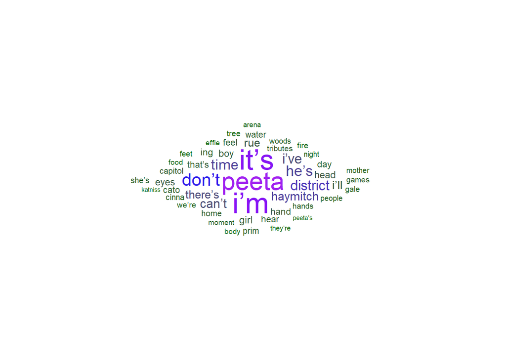

```r
#keep only the top 50 words
hg_top50 <- hg_no_numeric %>%
  count(word) %>%
  arrange(-n) %>%
  head(50)

# create a word cloud visualization to see the top 50 words
ggplot(data = hg_top50, aes(label = word, size = n)) +
  geom_text_wordcloud_area(aes(color = n), shape = "diamond") +
  scale_size_area(max_size = 10) +
  scale_color_gradientn(colors = c("darkgreen","blue","purple")) +
  theme_minimal()
```

Figure 1: Word Cloud of the Top 50 Words in Hunger Games by Suzanne Collins. Data from: https://archive.org/details/image_201902

#### Sentiment analysis

Using the three: - `get_sentiments(lexicon = "afinn")` - `get_sentiments(lexicon = "bing")` - `get_sentiments(lexicon = "nrc")`

```r
#join the hg_stop data frame with the afinn sentiments
hg_afinn <- hg_stop %>%
  inner_join(get_sentiments("afinn"))

#visualize the counts of the values to see the distribution of the words and their sentiments
hg_afinn_hist <- hg_afinn %>%
  count(value)

#graph it
#ggplot(data = hg_afinn_hist, aes(x = value, y = n))+
  #geom_col()
```

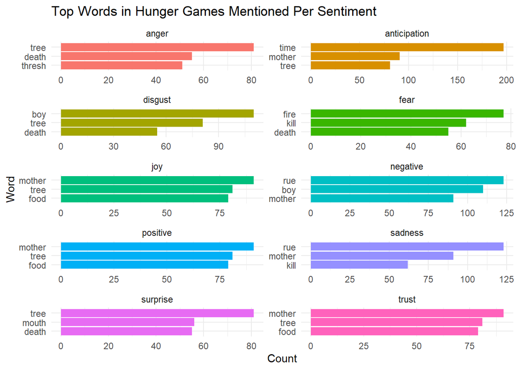

```r
#join the hg_stop data frame with the nrc sentiments
hg_nrc <- hg_stop %>%
  inner_join(get_sentiments("nrc"))

#count by sentiment to see the number of words for each
hg_nrc_n <- hg_nrc %>%
  count(sentiment, sort = TRUE)

#visualize the counts
#ggplot(data = hg_nrc_n, aes(x = sentiment, y = n))+
#  geom_col()+
#  coord_flip()

#group by the sentiment and and count, but only keep the top 5 words for each sentiment
hg_nrc_n3 <- hg_nrc %>%
  count(word, sentiment, sort = TRUE) %>%
  group_by(sentiment) %>%
  top_n(3) %>%
  ungroup()

#plot the sentiments and the top 5 words for each and use facet_wrap() to see all at once to compare
ggplot(data = hg_nrc_n3, aes(x = reorder(word,n), y = n, fill = sentiment)) +
  geom_col(show.legend = FALSE) +
  facet_wrap(~sentiment, ncol = 2, scales = "free") +
  coord_flip() +
  theme_minimal() +
  labs(x = "Word", y = "Count", title = "Top Words in Hunger Games Mentioned Per Sentiment")
```

Figure 2: Top 3 words mentioned in the book Hunger Games for each sentiment. Data from: https://archive.org/details/image_201902

In this analysis, the number of specific words and their abundance varies throughout the book, but the overall tone of the novel is more consistent. According to Figure 2, there are higher counts for anticipation, negative, sadness, and digust, setting an overall negative tone for the novel. Based on the book’s theme, this makes sense. However, in Figure 1, some of the invaluable words were not removed when using the stop_words vector, which may sway the top 50 words. Additionally, some of the words in the sentiment analysis are listed in multiple sentiments like mother and tree in both positive and anticipation. This may alter how we interpret the results.